# Intervention_Analysis_2016_Rio_Olympics

Prafulla Ranjan Dash

#### Here, we try and apply Intervention Analysis for the number of views time-series for the *2016_Summer_Olympics_en* webpage.

```r
# basic imports
library("fpp", lib.loc="C:/Users/HP/Anaconda3/envs/rstudio/lib/R/library")
library("ggplot2", lib.loc="C:/Users/HP/Anaconda3/envs/rstudio/lib/R/library")
library("stats", lib.loc="C:/Users/HP/Anaconda3/envs/rstudio/lib/R/library")
library("zoo", lib.loc="C:/Users/HP/Anaconda3/envs/rstudio/lib/R/library")
library("TSA", lib.loc="C:/Users/HP/Anaconda3/envs/rstudio/lib/R/library")
```

#### Importing the data

```r
setwd("D:/USMS/UChicago/STUDIES/Autumn 2020/MSCA 31006 1 Time Series Analysis and Forecasting/Final Project/Data")
page_2016_Rio_Olympics_views <- data.matrix(read.csv("train_1.csv", header = TRUE, row.names = 1,sep = ",",nrows = 1,skip = 12186))
```

#### Preparing data to make it ready for time-series

```r
# removing column names
dimnames(page_2016_Rio_Olympics_views) <- NULL

# converting to array
page_2016_Rio_Olympics_views <- array(page_2016_Rio_Olympics_views)

# checking the values
head(page_2016_Rio_Olympics_views)
```

```
## [1] 4893 4620 4000 3874 4385 7519
```

```r
# no. of ovservations
length(page_2016_Rio_Olympics_views)
```

```
## [1] 550
```

Looking at the entire data -

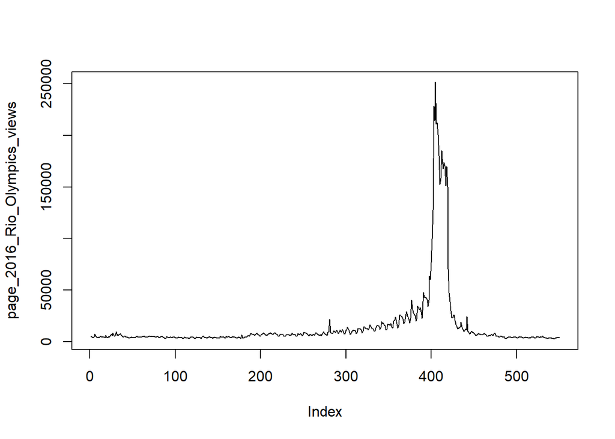

```r
plot(page_2016_Rio_Olympics_views,type = 'l')
```

Looking at this dataset, we can see there seems to be a an intervention at t = 175. So, we will take a sub-section of this data for our analysis.

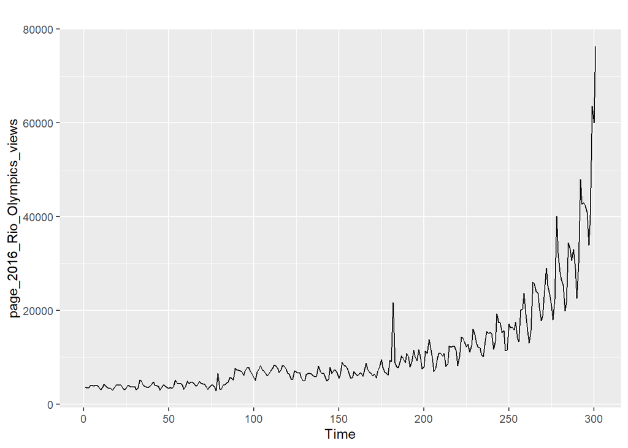

```r
page_2016_Rio_Olympics_views <- page_2016_Rio_Olympics_views[100:400]

# converting data to ts
page_2016_Rio_Olympics_views <- ts(page_2016_Rio_Olympics_views,frequency = 1)

# plotting the time-series
autoplot(page_2016_Rio_Olympics_views)
```

So, here we can clearly see some sort of **intervention** that took place at around the time-period of 75 days for this chunk of data (175 days overall). There is a clear **upward trend** after the time-period of 75 days.

Now, since the intervention is at time-period 75, we will divide our data into data-points prior to time-period 75 and post time-period 75. We will do this so that we can find the **underlying process** that is present in our observations, which are a **mix of the underlying process and the intervention**.

Now, looking at the dates, this intervention took place on **23rd Dec 2015**. And there was an article which was published in the *The Guardian* newspaper on **8th Dec 2015** that there have been widespread human right violations in Rio de Janeiro because of the evictions taking place for creating the infrastructure needed for conducting the Olympics. So, we believe this report of **Human rights violation related to Summer Olympics 2016** could have generated the curiosity amongst the readers which resulted in the increase in the upward trend for the number of views for this Wikipedia page.

```r
# splitting to prior and post intervention
page_2016_Rio_Olympics_views_prior <- page_2016_Rio_Olympics_views[1:75]
page_2016_Rio_Olympics_views_post <- page_2016_Rio_Olympics_views[76:300]

# converting to time-series
page_2016_Rio_Olympics_views_prior <- ts(page_2016_Rio_Olympics_views_prior)
page_2016_Rio_Olympics_views_post <- ts(page_2016_Rio_Olympics_views_post)
```

Now, let’s see how our prior intervention data looks

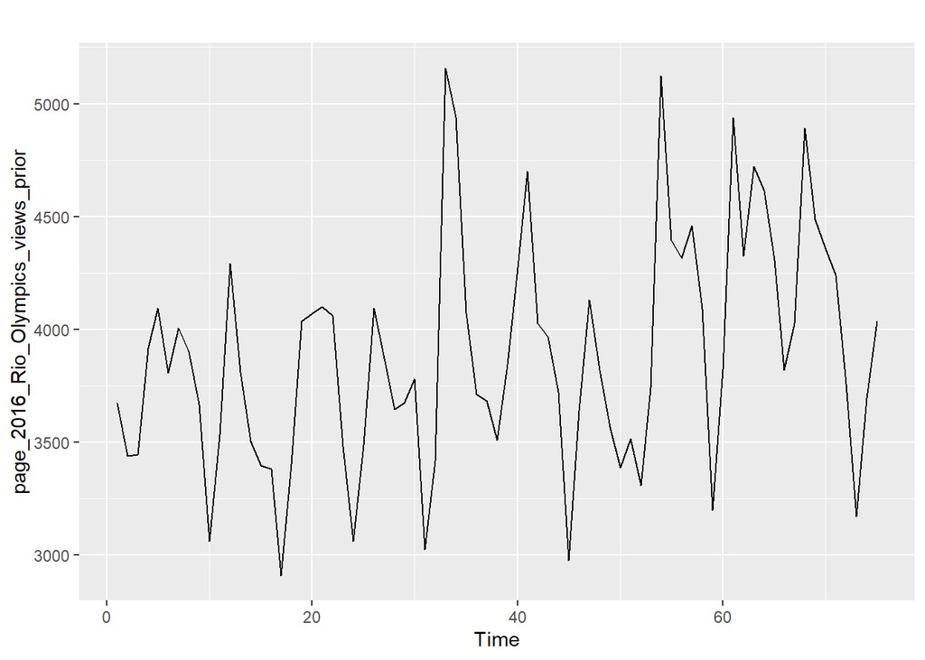

```r
autoplot(page_2016_Rio_Olympics_views_prior)
```

Looking at the data -

1. There is no visible non-seasonal trend.
2. There might be some seasonality where some patterns are repeating themselves.
3. The variance seems unstable, might require some Box-Cox transformation.

Applying Box-Cox -

```r
BoxCox.lambda(page_2016_Rio_Olympics_views_prior)
```

```
## [1] -0.6576963
```

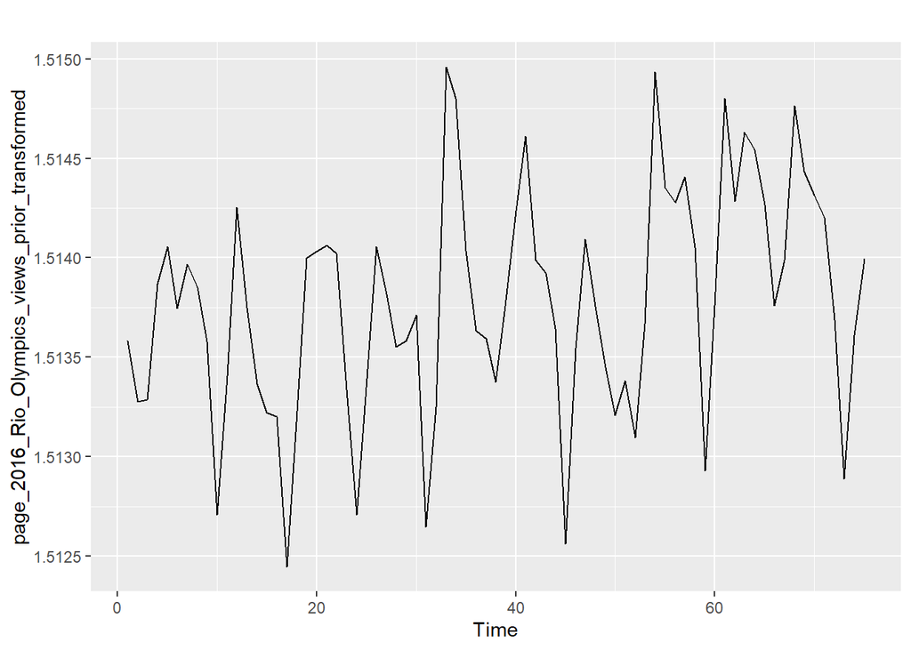

```r
page_2016_Rio_Olympics_views_prior_transformed <- BoxCox(page_2016_Rio_Olympics_views_prior,lambda = -0.6576963)

autoplot(page_2016_Rio_Olympics_views_prior_transformed)
```

The variance now seems to have stabilized a bit. Now, let’s look at the ACF and PACF for this signal.

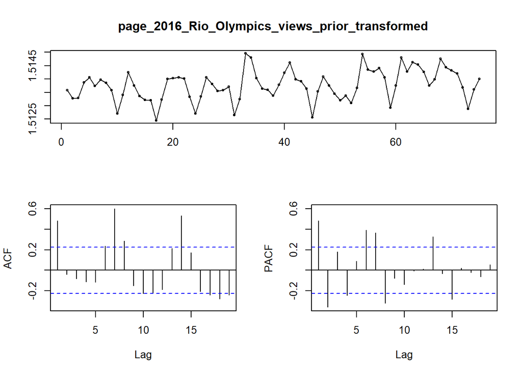

```r
tsdisplay(page_2016_Rio_Olympics_views_prior_transformed)
```

We can see from the ACF that our data is **not stationary** as there are significant spikes along with a sinusoidal component. Let’s apply one order of non-seasonal differencing.

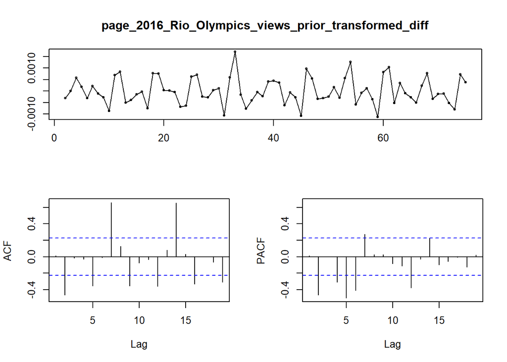

```r
# differencing
page_2016_Rio_Olympics_views_prior_transformed_diff <- diff(page_2016_Rio_Olympics_views_prior_transformed)

# visulalizing
tsdisplay(page_2016_Rio_Olympics_views_prior_transformed_diff)
```

one order of seasonal differencing

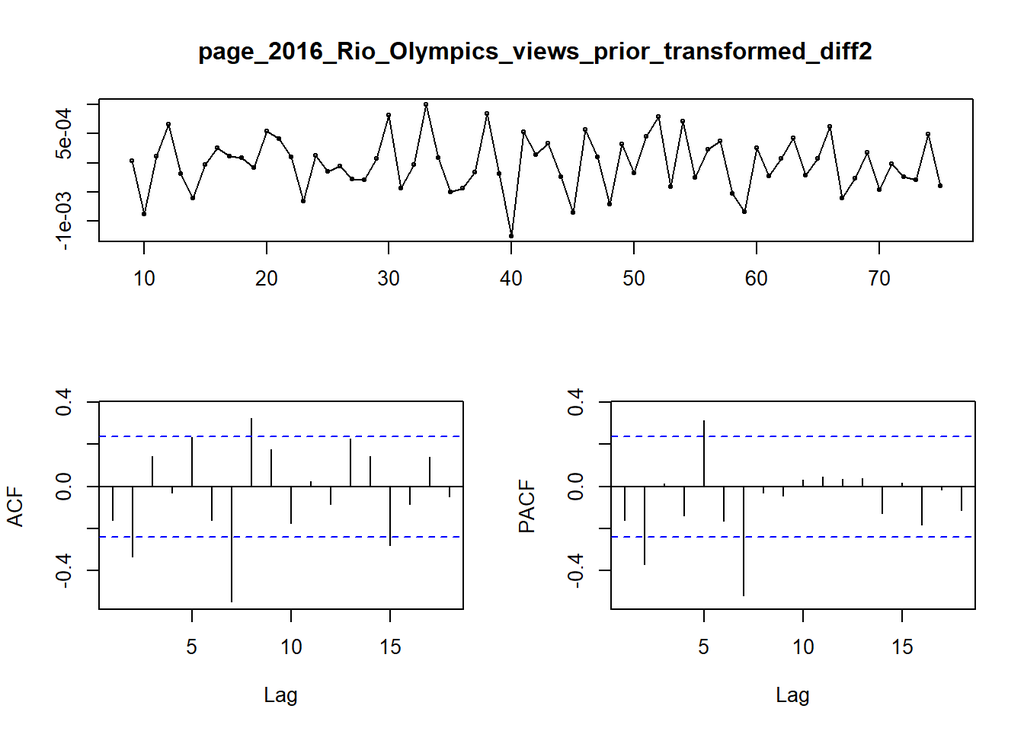

```r
# differencing
page_2016_Rio_Olympics_views_prior_transformed_diff2 <- diff(page_2016_Rio_Olympics_views_prior_transformed_diff,lag = 7)

# visulalizing
tsdisplay(page_2016_Rio_Olympics_views_prior_transformed_diff2)
```

We see that the data still does not appear stationary. There is 1 very significant spike at lag 7.

Let’s allow auto.arima to decide the best model for this data.

```r
# applying auto.arima
m_prior <- auto.arima(page_2016_Rio_Olympics_views_prior,lambda = 'auto')

# checking the model
summary(m_prior)
```

```
## Series: page_2016_Rio_Olympics_views_prior
## ARIMA(5,1,2)
## Box Cox transformation: lambda= -0.6576963
##
## Coefficients:
##          ar1      ar2     ar3      ar4      ar5      ma1     ma2
##       0.4983  -0.9792  0.0683  -0.4734  -0.3252  -0.9031  0.7719
## s.e.  0.1410   0.1172  0.1772   0.1177   0.1333   0.1191  0.0785
##
## sigma^2 estimated as 1.706e-07:  log likelihood=481.31
## AIC=-946.61   AICc=-944.4   BIC=-928.18
##
## Training set error measures:
##                    ME     RMSE      MAE       MPE     MAPE      MASE
## Training set 32.38213 335.0929 261.5073 0.3197846 6.715077 0.6498603
##                    ACF1
## Training set 0.01259144
```

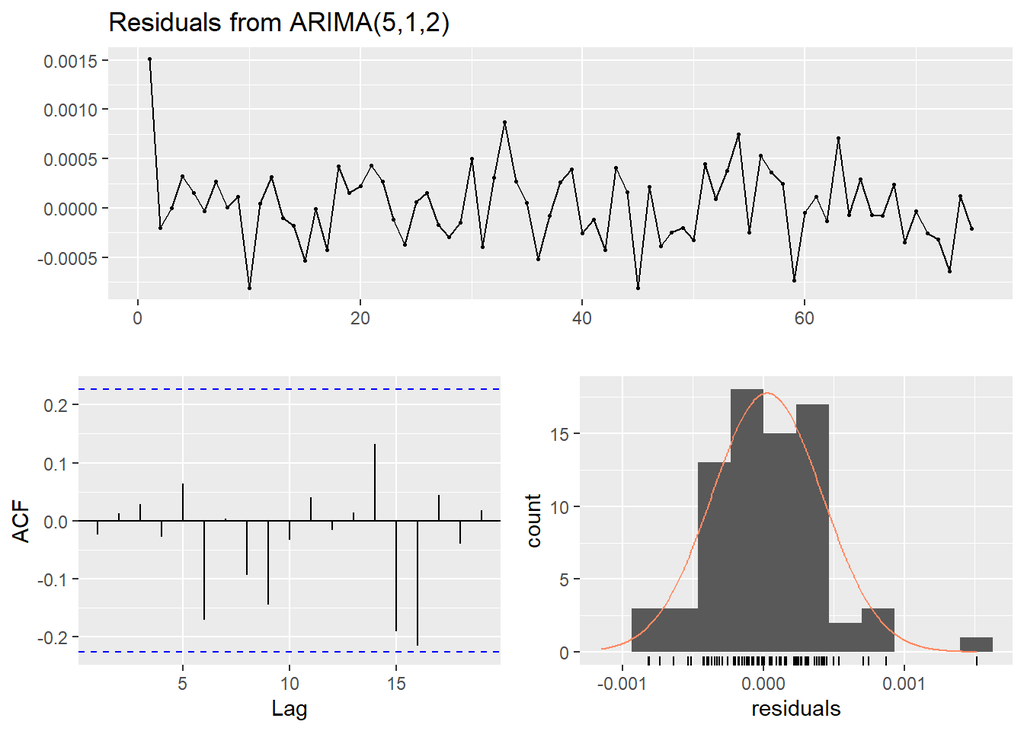

```
##
##  Ljung-Box test
##
## data:  Residuals from ARIMA(5,1,2)
## Q* = 5.6956, df = 3, p-value = 0.1274
##
## Model df: 7.   Total lags used: 10
```

```r
# diagnozing model - residuals
checkresiduals(m_prior)
```

So, we see that the underlying process here is ARIMA(5,1,2). The residuals here seem to be white noise as there are no significant spikes for ACF of residuals. Looking at the residuals time-series, there is one outlier.

Now, although this model is giving us white noise residuals, this model is quite **complex** because the order of the AR part is = 5, which is pretty high.

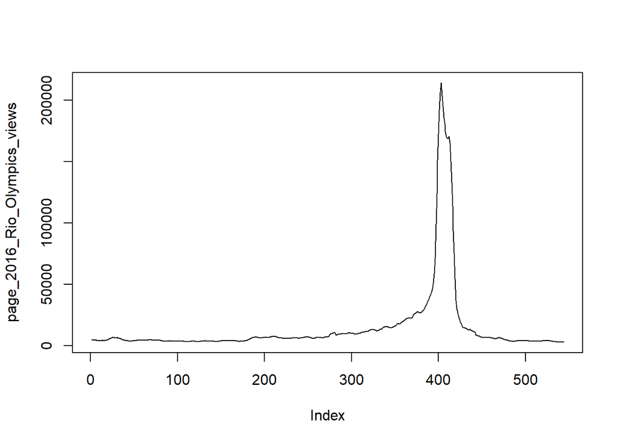

```r
# reading data again
setwd("D:/USMS/UChicago/STUDIES/Autumn 2020/MSCA 31006 1 Time Series Analysis and Forecasting/Final Project/Data")
page_2016_Rio_Olympics_views <- data.matrix(read.csv("train_1.csv", header = TRUE, row.names = 1,sep = ",",nrows = 1,skip = 12186))

# removing column names
dimnames(page_2016_Rio_Olympics_views) <- NULL

# converting to array
page_2016_Rio_Olympics_views <- array(page_2016_Rio_Olympics_views)

# downsampling
page_2016_Rio_Olympics_views <- rollapply(page_2016_Rio_Olympics_views, 7, mean)

# plotting
plot(page_2016_Rio_Olympics_views,type = 'l')
```

This downsampled data looks much smoother.

Now, taking a chunk of this data as previously -

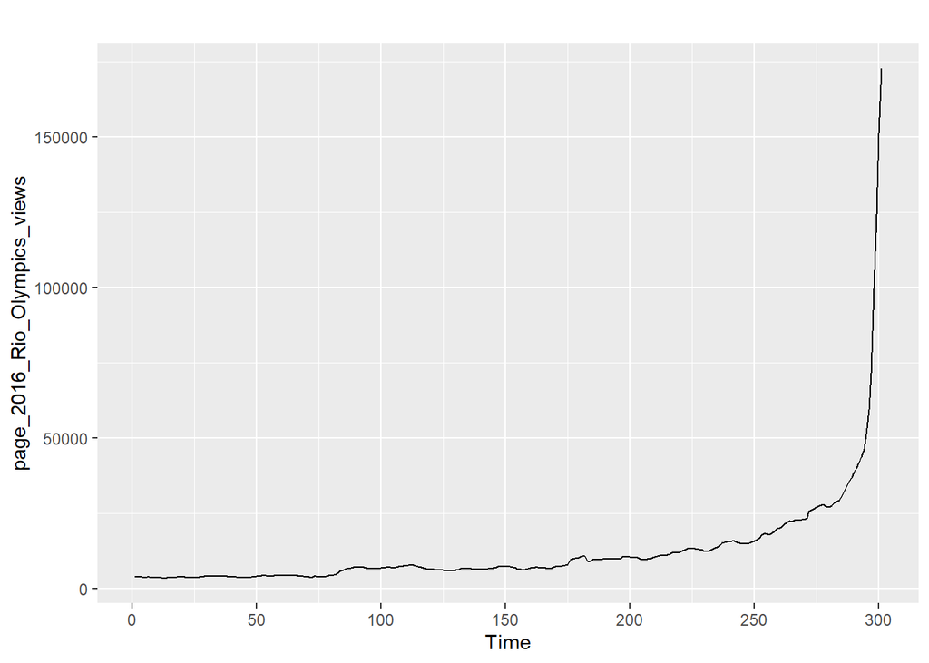

```r
page_2016_Rio_Olympics_views <- page_2016_Rio_Olympics_views[100:400]

# converting data to ts
page_2016_Rio_Olympics_views <- ts(page_2016_Rio_Olympics_views,frequency = 1)

# plotting the time-series
autoplot(page_2016_Rio_Olympics_views)
```

Splitting to pre and post intervention

```r
# splitting to prior and post intervention
page_2016_Rio_Olympics_views_prior <- page_2016_Rio_Olympics_views[1:75]
page_2016_Rio_Olympics_views_post <- page_2016_Rio_Olympics_views[76:300]

# converting to time-series
page_2016_Rio_Olympics_views_prior <- ts(page_2016_Rio_Olympics_views_prior)
page_2016_Rio_Olympics_views_post <- ts(page_2016_Rio_Olympics_views_post)
```

Now, let’s see how our prior intervention data looks

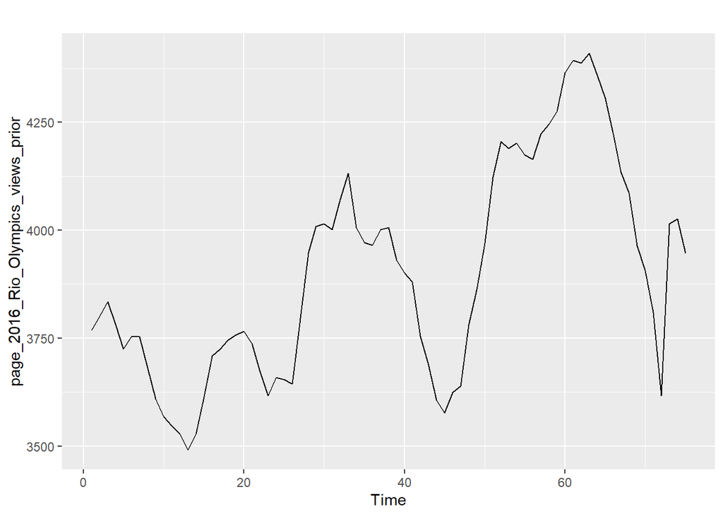

```r
autoplot(page_2016_Rio_Olympics_views_prior)
```

Looking at this data -

1. It definitely needs some Box Cox transformatio as the variance of the data is increasing with time.
2. There might be some seasonality.
3. There is no obvious trend.

Let’s allow auto.arima to decide the best model for this data.

```r
# applying auto.arima
m2_prior <- auto.arima(page_2016_Rio_Olympics_views_prior,lambda = 'auto')

# checking the model
summary(m2_prior)
```

```
## Series: page_2016_Rio_Olympics_views_prior
## ARIMA(1,1,1)
## Box Cox transformation: lambda= 1.999924
##
## Coefficients:
##           ar1     ma1
##       -0.6978  0.9795
## s.e.   0.1097  0.0882
##
## sigma^2 estimated as 9.222e+10:  log likelihood=-1038.91
## AIC=2083.82   AICc=2084.16   BIC=2090.73
##
## Training set error measures:
##                    ME     RMSE      MAE       MPE     MAPE      MASE
## Training set 2.760552 77.13401 53.26885 0.0541922 1.369109 0.9094682
##                    ACF1
## Training set 0.03866583
```

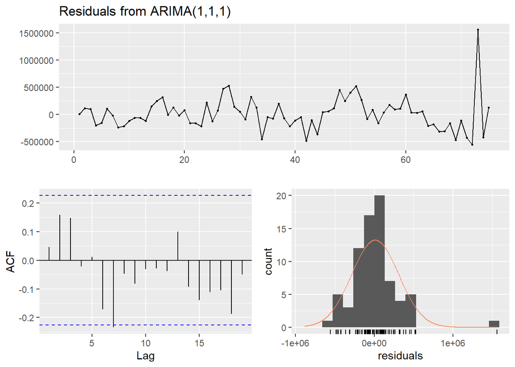

```
##
##  Ljung-Box test
##
## data:  Residuals from ARIMA(1,1,1)
## Q* = 11.953, df = 8, p-value = 0.1533
##
## Model df: 2.   Total lags used: 10
```

```r
# diagnozing model - residuals
checkresiduals(m2_prior)
```

So, we see this time, our model for prior data is **much simpler**, its **ARIMA(1,1,1)** and looking at the residuals - 1. The time-series of residuals indicate the mean of the residuals is zero with one outlier  
2. The ACF of residuals indicate that they are white noise

This implies this model was able to capture the systematic patterns in our prior data and this is our **underlying process**.

Now, let’s see how the forecasts for this model looks.

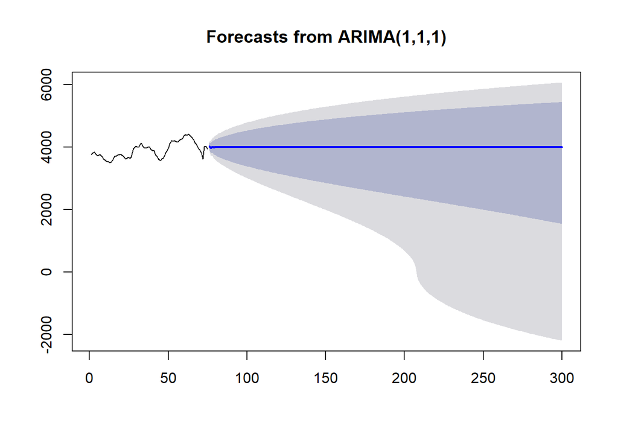

```r
# forecasting
m2_prior_forecast <- forecast(m2_prior,h = 225)

# plotting the forecasts
plot(m2_prior_forecast)
```

This is how the time-series would have looked if there was no intervention. Now, let’s try and analyze what could be the transfer function that represents the intervention correctly.

For this, we can just subtract the underlying process from the observations. That will give us the intervention. We tried some combinations for the intervention transfer function.

We suspect that the intervention can be described as ARMA(2,2) process. For this, we kind of did trial and error for various processes like AR(1), AR(2), ARMA(1,1) etc. And we saw that the ARMA(2,2) process gave us a shape that was closer to the shape of our intervention.

```r
# storing the point of intervention
IHRV <- 1*(seq(page_2016_Rio_Olympics_views)==75)

# applying the model
page_views_intervention_model <- arimax(log(page_2016_Rio_Olympics_views), order = c(1,1,1),
                            xtransf = data.frame(IHRV),
                            transfer = list(c(2,2)),
                            xreg = 1*(seq(page_2016_Rio_Olympics_views)==175),
                            method = 'ML'
)
# viewing the model
page_views_intervention_model
```

```
##
## Call:
## arimax(x = log(page_2016_Rio_Olympics_views), order = c(1, 1, 1), xreg = 1 *
##     (seq(page_2016_Rio_Olympics_views) == 175), method = "ML", xtransf = data.frame(IHRV),
##     transfer = list(c(2, 2)))
##
## Coefficients:
##          ar1      ma1     xreg  IHRV-AR1  IHRV-AR2  IHRV-MA0  IHRV-MA1
##       0.8637  -0.2707  -0.0927    1.0836   -0.1840   -0.0425   -0.0210
## s.e.  0.0456   0.0810   0.0148    0.8783    0.7929    0.0268    0.0394
##       IHRV-MA2
##        -0.0256
## s.e.    0.0304
##
## sigma^2 estimated as 0.00082:  log likelihood = 635.53,  aic = -1255.05
```

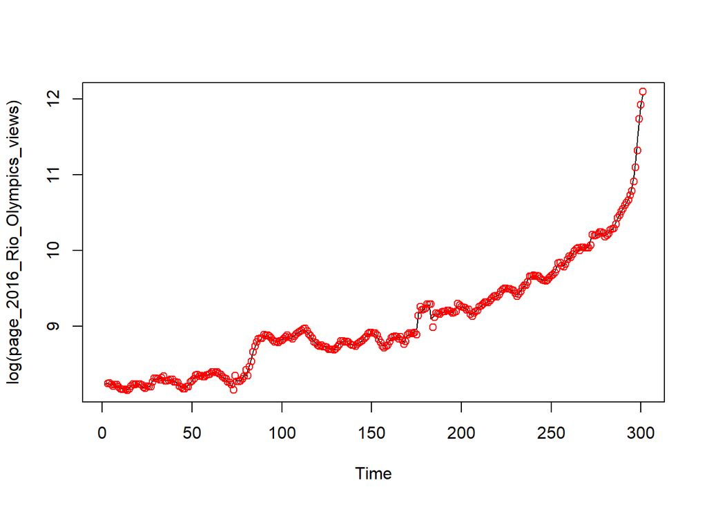

```r
# plotting the actual and the fitted values in log scale
plot(log(page_2016_Rio_Olympics_views))
points(fitted(page_views_intervention_model),col = 'red')
```

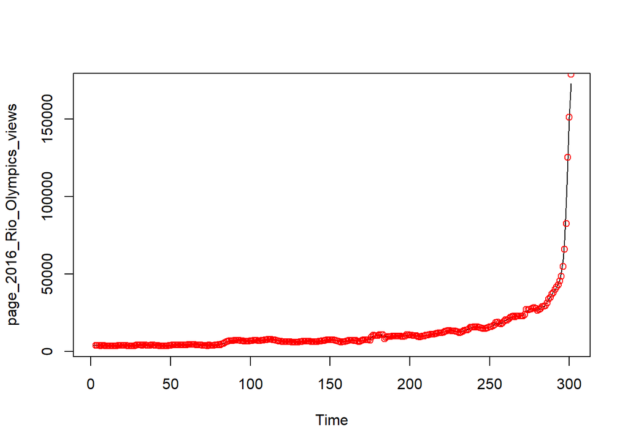

```r
# plotting the actual and fitted in normal scale
plot(page_2016_Rio_Olympics_views)
points(exp(fitted(page_views_intervention_model)),col = 'red')
```

Here we applied the **Regression with ARMA error** for capturing the underlying unperturbed process and the intervention. We also included one additive outlier at t = 175. Here additive outlier may be regarded as interventions of unknown nature that have a pulse response function.

The black line denotes the actual observations and the red circles represent the fitted values from the model. We see that the model has performed pretty well here.

We assumed that the transfer function that can represent the intervention is an ARMA(2,2) function and we used the coefficients got from here to plot the intervention below.

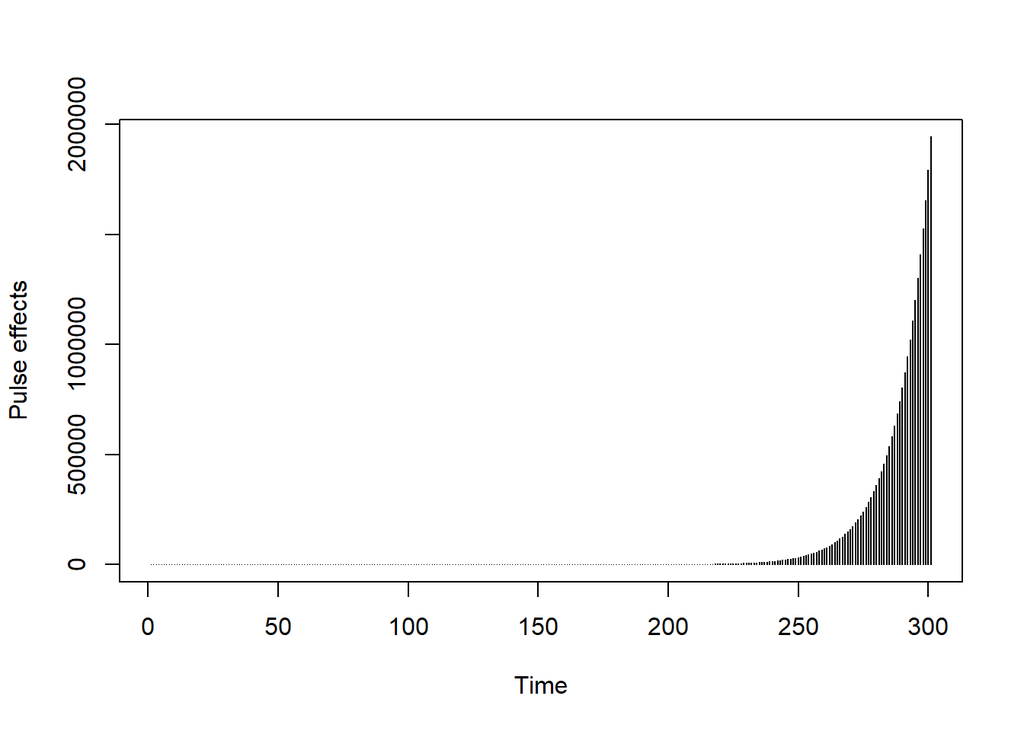

```r
plot(ts(IHRV*(-0.0425)+filter(IHRV,filter = 1.0836, method = 'recursive', sides = 1)*(0.0256)),
     type = 'h',ylab = 'Pulse effects'
     )
```

The above may be the intervention that took place.

Now, let’s check the residuals of this model, how they performed.

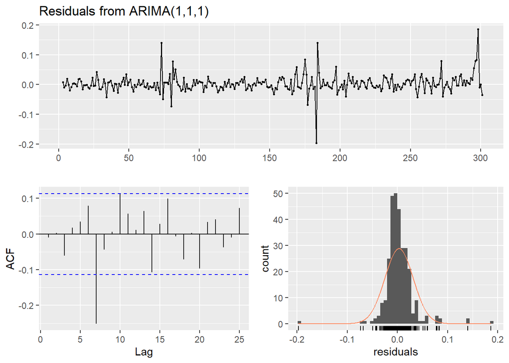

```
##
##  Ljung-Box test
##
## data:  Residuals from ARIMA(1,1,1)
## Q* = 28.671, df = 3, p-value = 2.626e-06
##
## Model df: 8.   Total lags used: 11
```

```r
checkresiduals(page_views_intervention_model)
```

Looking at the residuals –

1. From time-series we can see that the mean of the residuals are almost equal to zero, but there are few outliers.
2. From ACF we can see that the residuals are not white noise because there is a significant spike at lag 7, even though all other spikes are not significant.
3. The same outliers can also be seen in the histogram of residuals.

So, We have to keep improving our model further and try applying other appropriate transfer functions that can represent the intervention that we have over here.